# Examine the association between gene expression and age_group variable (fetus vs adult)

Vy K Phung

## Introduction

The purpose of this re-analysis is to examine the correlation of differential gene expression between fetal and adult brains, which is evaluated through RNA-sequencing. If it has correlation, then count how many up-regulated and down-regulated genes. I will do exploratory analysis and statistical analysis by using R, RStudio.

## Load library

```r
library(tidyverse)
library(limma)
library(preprocessCore)
library(RColorBrewer)
library(org.Hs.eg.db)
library(AnnotationDbi)
library(edge)
library(sva)
library(DESeq2)
library(broom)
library(readxl)
```

## Data preprocessing

```r
count <- read.delim("D:/word/bioinformatics/personal project/PRJNA245228/tidy data/count.csv")
pheno <- read.csv("D:/word/bioinformatics/personal project/PRJNA245228/sample_data/pheno_sample.csv")
head(count)
```

```
##   ENTREZID         ENSEMBL SYMBOL SRR1554534 SRR1554535 SRR1554568 SRR1554561
## 1        1 ENSG00000121410   A1BG        444        378        328        650
## 2       10 ENSG00000156006   NAT2         11          8          4          0
## 3      100 ENSG00000196839    ADA        299        658        161        229
## 4     1000 ENSG00000170558   CDH2       7384      10623      43926      11016
## 5    10000 ENSG00000117020   AKT3       6837       7391      90930      13677
## 6    10000 ENSG00000275199   AKT3       6837       7391      90930      13677
##   SRR1554567 SRR1554536 SRR1554541 SRR1554539 SRR1554538 SRR1554537
## 1        146        114        592        295        275        518
## 2          8          0          8          8         12          4
## 3        225        291        382        265        354        160
## 4      52746       3270      44244      10639      47354      52346
## 5      36246        937      74768      18216      48565      79685
## 6      36246        937      74768      18216      48565      79685
```

```r
head(pheno)
```

```
##          Run age_group     age    sex
## 1 SRR1554534     adult 40.4200   male
## 2 SRR1554535     adult 41.5800   male
## 3 SRR1554568     fetus -0.4986   male
## 4 SRR1554561     adult 43.8800   male
## 5 SRR1554567     fetus -0.4027   male
## 6 SRR1554536     adult 44.1700 female
```

It is clear that there are some duplications in columns “SYMBOL”(gene symbol) and “ENTREZID”, for example, in line 5,6 of “count” table. I will remove duplicated genes and use gene symbol as row name.

```r
dup <- duplicated(count$SYMBOL)
table(dup)
```

```
## dup
## FALSE  TRUE
## 23741  4955
```

```r
count_symbol<- count[!dup,-1:-2]
na <- is.na(count_symbol$SYMBOL)
count_symbol <- count_symbol[!na,]
row.names(count_symbol) <- count_symbol$SYMBOL
count_symbol <- count_symbol[,-1]
head(count_symbol)
```

```
##         SRR1554534 SRR1554535 SRR1554568 SRR1554561 SRR1554567 SRR1554536
## A1BG           444        378        328        650        146        114
## NAT2            11          8          4          0          8          0
## ADA            299        658        161        229        225        291
## CDH2          7384      10623      43926      11016      52746       3270
## AKT3          6837       7391      90930      13677      36246        937
## GAGE12F          0          0          0          0          0          0
##         SRR1554541 SRR1554539 SRR1554538 SRR1554537
## A1BG           592        295        275        518
## NAT2             8          8         12          4
## ADA            382        265        354        160
## CDH2         44244      10639      47354      52346
## AKT3         74768      18216      48565      79685
## GAGE12F          0          0          0          0
```

## Data exploration

Although the target of this exploratory analysis is figuring out if there is a correlation between differential gene expression in fetus vs adult brains, I still plot PCA for the sex group in this data exploration to have a brief overview if there might be an association between sex variable (female vs male) with gene expression in fetus vs adult.

At first, I will explore unfiltered data which still has some genes’ row names having 0 reads in “count_symbol” table by using DESeq2.

### Unfiltered data

```r
library(DESeq2)
edata <- DESeqDataSetFromMatrix(countData = count_symbol, colData = pheno, design = ~ age_group)
```

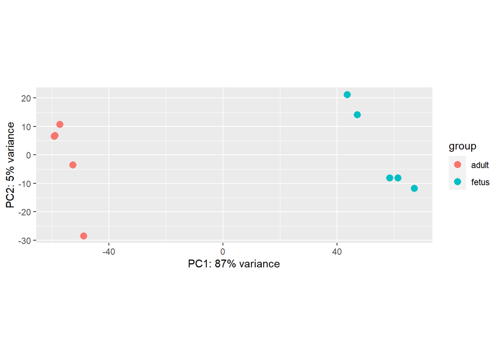

```r
edata_tr <- rlog(edata, blind = FALSE)
plotPCA(edata_tr, intgroup = c("age_group"))
```

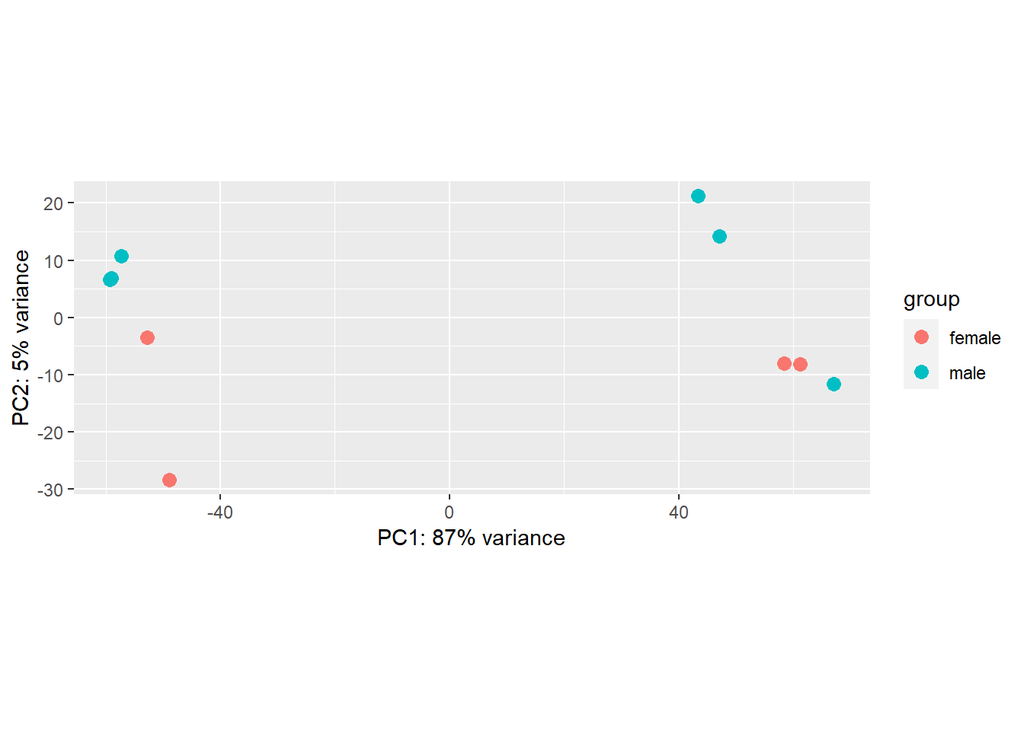

```r
plotPCA(edata_tr, intgroup = c("sex"))
```

According to plotPCA having intgroup “age_group”, there can be an association between differential gene expression and age_group(fetus vs adult). However, in plotPCA having intgroup “sex”, we can see that there might be no association between gender and gene expression.

I will also show the table of data transform of the above count_symbol table and the cluster of it in Dendogram so that we could easily visualize the correlation between those samples.

```r
edata_tr <- assay(edata_tr)
head(edata_tr)
```

```
##         SRR1554534 SRR1554535 SRR1554568 SRR1554561 SRR1554567 SRR1554536
## A1BG      9.190681   8.591025   8.087121   9.266152   6.808106   8.754521
## NAT2      2.898727   2.564131   2.169268   1.840736   2.306952   1.945286
## ADA       8.671241   9.225800   7.208636   7.967730   7.255809   9.862274
## CDH2     13.536261  13.571832  14.972885  13.633542  14.836363  13.764138
## AKT3     13.453204  13.144329  15.892417  13.906920  14.381850  12.281291
## GAGE12F   0.000000   0.000000   0.000000   0.000000   0.000000   0.000000
##         SRR1554541 SRR1554539 SRR1554538 SRR1554537
## A1BG      8.388780   8.418109   7.553544   8.518947
## NAT2      2.289385   2.615617   2.494186   2.140643
## ADA       7.824756   8.248514   7.806678   7.090937
## CDH2     14.563325  13.699760  14.722689  15.072426
## AKT3     15.224047  14.367595  14.763178  15.606567
## GAGE12F   0.000000   0.000000   0.000000   0.000000
```

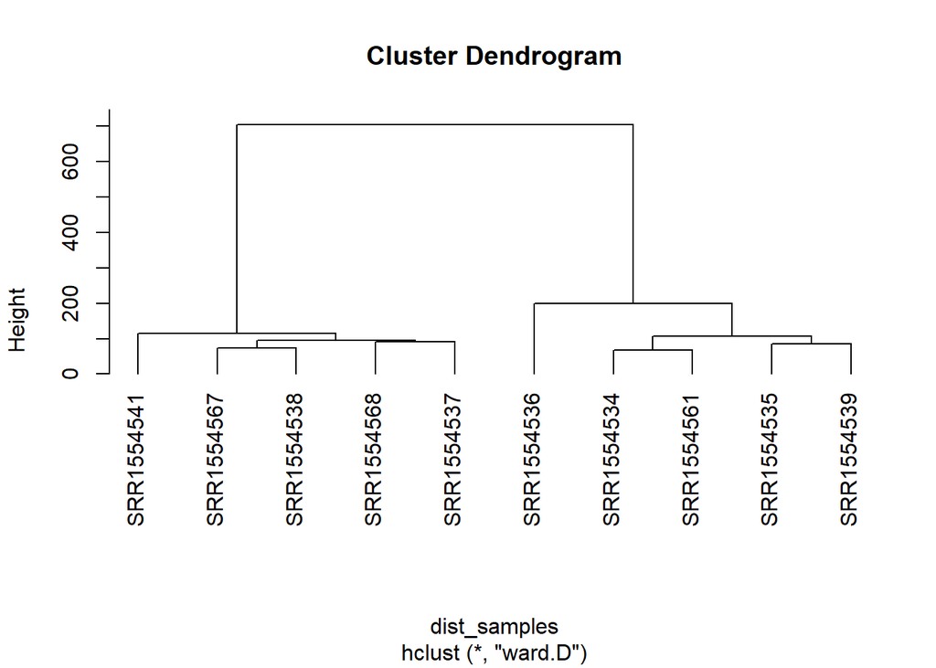

```r
dist_samples <- dist(t(edata_tr))
gene_fit <- hclust(dist_samples, method="ward.D")
plot(gene_fit, hang=-1)
```

According to cluster Dendogram, there are 2 main branches. The smaller branches SRR15545(41,67,38,68,37) on the main left are fetus group, while the others on the main right are in adult group. This visualization reinforces the hypothesis that there can be a correlation between differential gene expression in fetus vs adult.

Additionally, I also visualize the frequency of number of reads in the count table when data has been transformed on histogram and boxplot. We can see that mostly the reads are below 20 and in the range between 5 to 15.

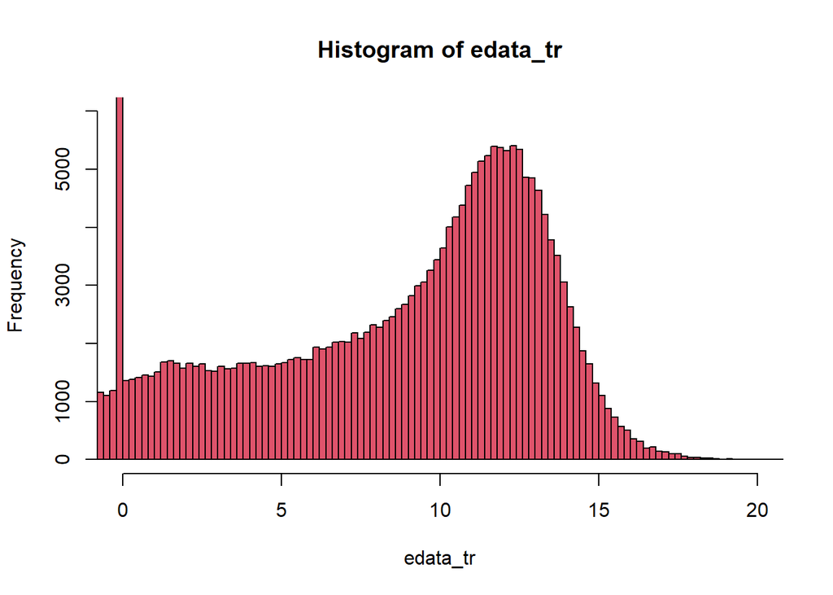

```r
hist(edata_tr,breaks=100,col=2,xlim=c(0,20),ylim=c(0,6000))
```

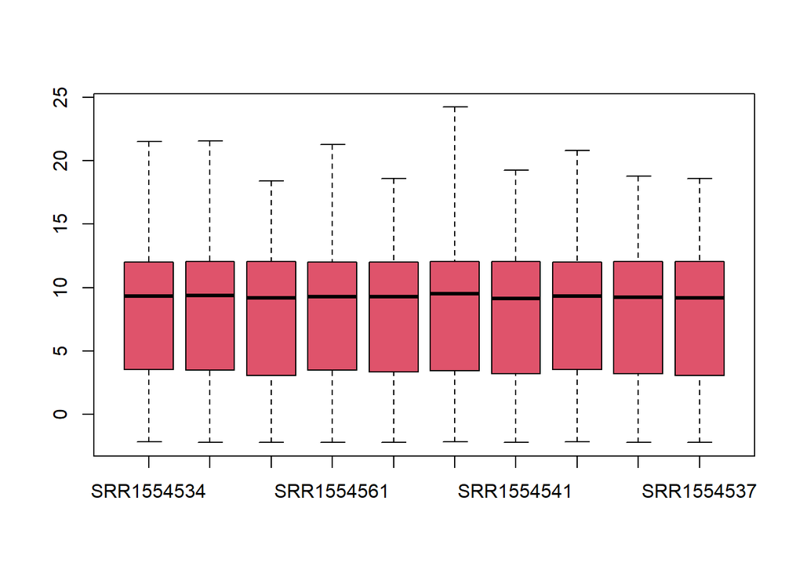

```r
boxplot(edata_tr,col=2,range=0)
```

### Filtered data

Removing lowly expressed genes and using DESeq to explore data as the same way as above unfiltered data in order to see if there are any differences between filtered and unfiltered one.

```r
count_filter = count_symbol[rowMeans(count_symbol) > 100,]
edata <- DESeqDataSetFromMatrix(countData = count_filter, colData = pheno, design = ~ age_group)
```

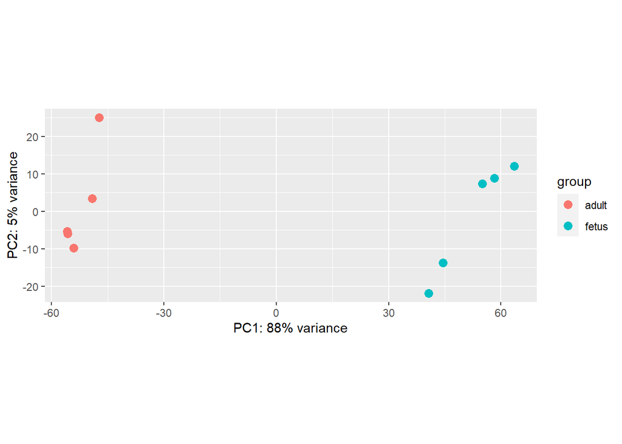

```r
edata_tr <- rlog(edata, blind = FALSE)
plotPCA(edata_tr, intgroup = c("age_group"))
```

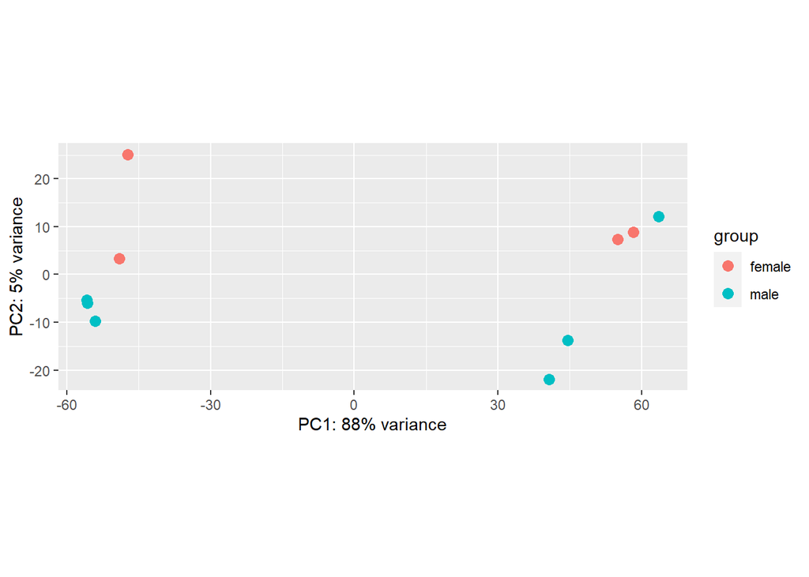

```r
plotPCA(edata_tr, intgroup = c("sex"))
```

```r
edata_tr <- assay(edata_tr)
head(edata_tr)
```

```
##            SRR1554534 SRR1554535 SRR1554568 SRR1554561 SRR1554567 SRR1554536
## A1BG         9.143633   8.583227   8.105891   9.206773   6.995598   8.762864
## ADA          8.646385   9.145974   7.303994   8.001912   7.351627   9.770115
## CDH2        13.562468  13.585906  14.957846  13.652418  14.829826  13.812075
## AKT3        13.479431  13.159273  15.876052  13.925121  14.376621  12.332018
## ZBTB11-AS1   7.746129   7.539217   7.489181   7.323988   7.706548   7.731734
## MED6        10.965760  10.953407  11.062971  10.825176  11.161363  10.689913
##            SRR1554541 SRR1554539 SRR1554538 SRR1554537
## A1BG         8.373665   8.429514   7.632873   8.489938
## ADA          7.843839   8.253862   7.831596   7.197164
## CDH2        14.545283  13.717079  14.708753  15.051336
## AKT3        15.204848  14.383520  14.749481  15.584859
## ZBTB11-AS1   7.684944   7.654166   7.625887   7.705363
## MED6        11.229573  11.095095  11.270915  11.087431
```

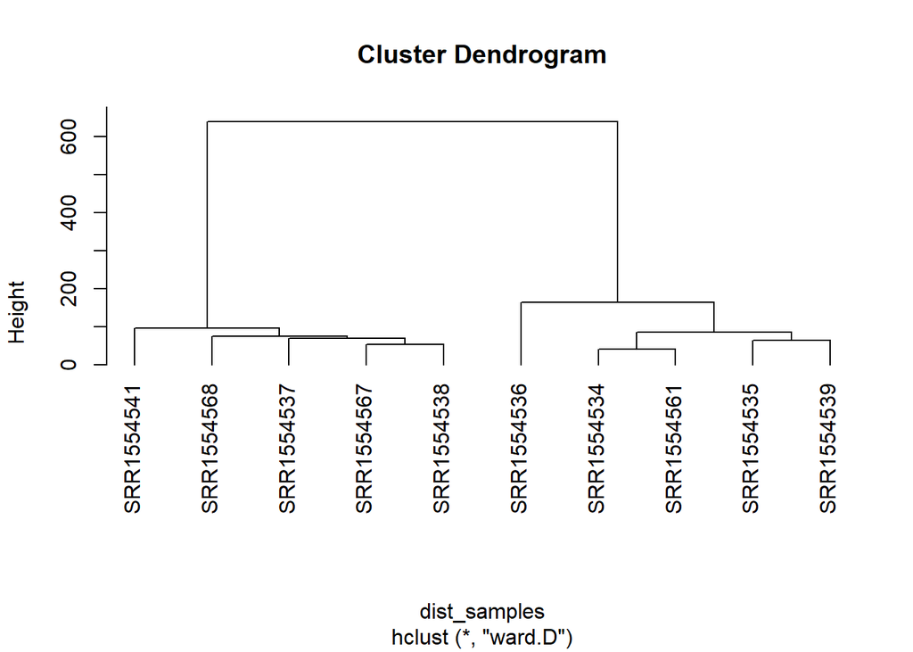

```r
dist_samples <- dist(t(edata_tr))
gene_fit <- hclust(dist_samples, method="ward.D")
plot(gene_fit, hang=-1)
```

We can see that there is almost no difference in the results of unfiltered and filtered data except on the cluster Dendogram of filtered one, the relation between SRR1554568 and SRR1554537 are not close-related as same as that of unfiltered.

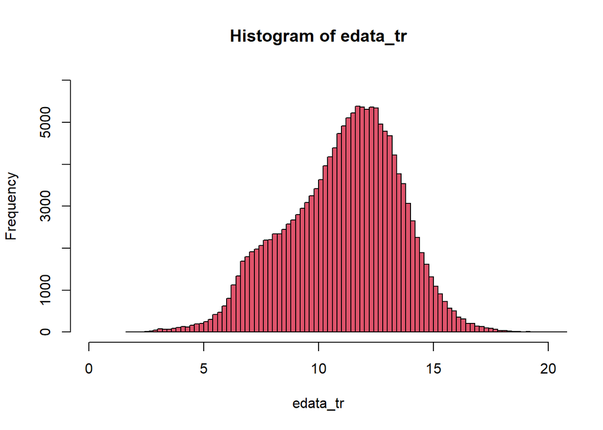

```r
hist(edata_tr,breaks=100,col=2,xlim=c(0,20),ylim=c(0,6000))
```

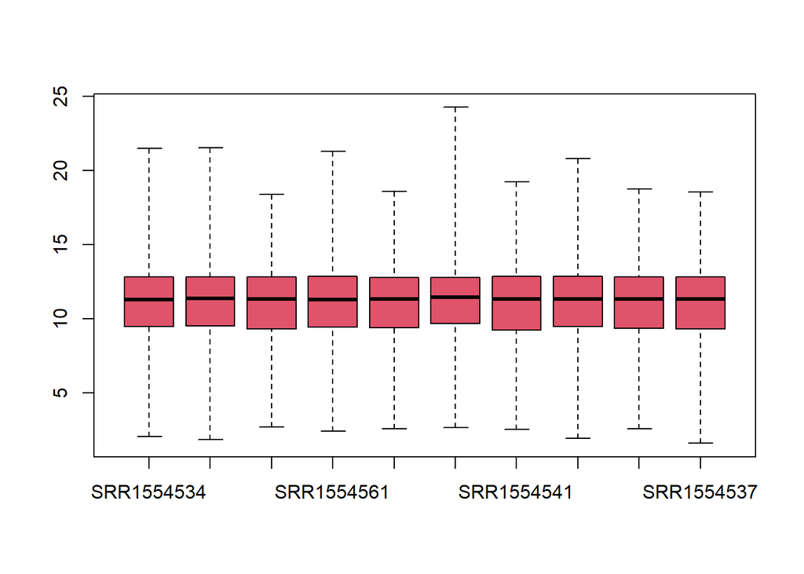

```r
boxplot(edata_tr,col=2,range=0)
```

### Stratified analysis

Because I want to explore if the sex variable (male vs female) might effect the association between age_group variable and gene expression, I get the female data in 10 samples above and analyse the factor age_group in this gender and do the same with the male gender.

#### Female

There are 4/10 samples having sex is female

```r
pheno_female = pheno[pheno$sex == "female",]
pheno_female
```

```
##           Run age_group     age    sex
## 6  SRR1554536     adult 44.1700 female
## 8  SRR1554539     adult 36.5000 female
## 9  SRR1554538     fetus -0.4027 female
## 10 SRR1554537     fetus -0.3836 female
```

```r
female_run <- (colnames(count_symbol) %in% pheno_female$Run)
table(female_run)
```

```
## female_run
## FALSE  TRUE
##     6     4
```

```r
count_female = count_symbol[,female_run]
head(count_female)
```

```
##         SRR1554536 SRR1554539 SRR1554538 SRR1554537
## A1BG           114        295        275        518
## NAT2             0          8         12          4
## ADA            291        265        354        160
## CDH2          3270      10639      47354      52346
## AKT3           937      18216      48565      79685
## GAGE12F          0          0          0          0
```

```r
edata_fe <- DESeqDataSetFromMatrix(count_female, pheno_female, ~age_group)
```

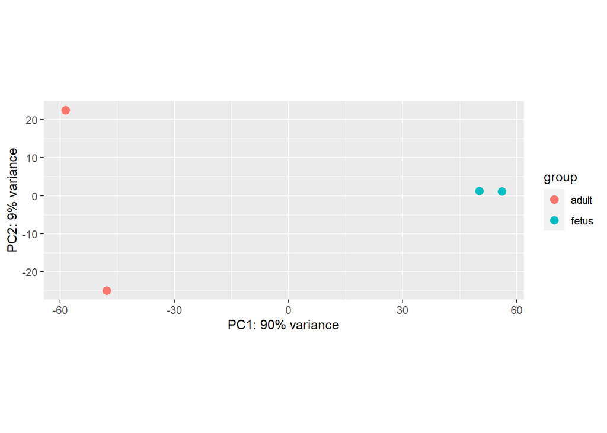

```r
edata_fe_tr <- rlog(edata_fe, blind = FALSE)
plotPCA(edata_fe_tr, intgroup = c("age_group"))
```

#### Male

```r
pheno_male = pheno[pheno$sex == "male",]
pheno_male
```

```
##          Run age_group     age  sex
## 1 SRR1554534     adult 40.4200 male
## 2 SRR1554535     adult 41.5800 male
## 3 SRR1554568     fetus -0.4986 male
## 4 SRR1554561     adult 43.8800 male
## 5 SRR1554567     fetus -0.4027 male
## 7 SRR1554541     fetus -0.3836 male
```

```r
male_run <- (colnames(count_symbol) %in% pheno_male$Run)
table(male_run)
```

```
## male_run
## FALSE  TRUE
##     4     6
```

```r
count_male = count_symbol[,male_run]
head(count_male)
```

```
##         SRR1554534 SRR1554535 SRR1554568 SRR1554561 SRR1554567 SRR1554541
## A1BG           444        378        328        650        146        592
## NAT2            11          8          4          0          8          8
## ADA            299        658        161        229        225        382
## CDH2          7384      10623      43926      11016      52746      44244
## AKT3          6837       7391      90930      13677      36246      74768
## GAGE12F          0          0          0          0          0          0
```

```r
edata_ma <- DESeqDataSetFromMatrix(count_male, pheno_male, ~age_group)
```

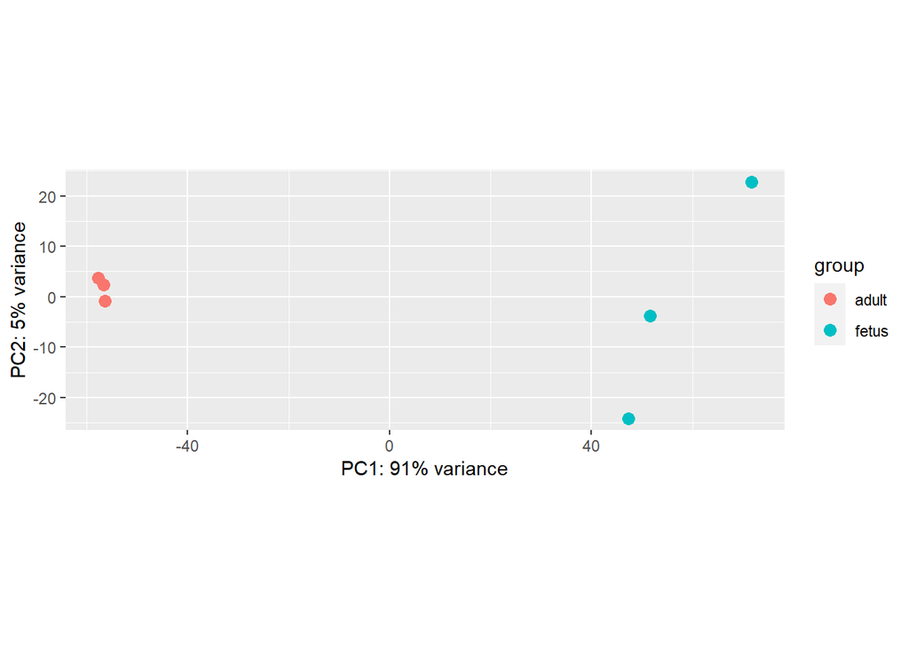

```r
edata_ma_tr <- rlog(edata_ma, blind = FALSE)
plotPCA(edata_ma_tr, intgroup = c("age_group"))
```

For both female and male, the visualization of plotPCA shows that there still can be an association between gene expression with age_group variable(fetus vs adult).

## Statistical analysis

The target of this statistical analysis is examining the correlation between age_group variable (fetus or adult) and gene expression more clearly so that in the end I will count up and down regulated genes.

In this statistical analysis, I will use limma package and DESeq package to see if there are any different results between two methods.

I will use DEseq package to analyze edata (output of DESeq) and Limma package to analyze edata_tr (edata has been transformed)

### Unadjusted data

At first, I will analyze statistically variable age_group without adjustment factor (sex variable).

#### Fit regression with limma package

```r
# age_group
mod_age = model.matrix(~ pheno$age_group)
fit_limma_age = lmFit(edata_tr,mod_age)
ebayes_limma_age = eBayes(fit_limma_age)
re = topTable(ebayes_limma_age, number=dim(count_symbol)[1])
head(re)
```

```
##             logFC   AveExpr         t      P.Value    adj.P.Val        B
## ST8SIA2  6.264017 11.767199  40.30384 2.684402e-13 2.770718e-09 20.15611
## SOX11    7.196578 13.549118  39.27425 3.561563e-13 2.770718e-09 19.94839
## TRIM54  -6.448248  6.397455 -34.32829 1.547426e-12 8.025467e-09 18.81527
## SLA      5.755159 12.718546  33.37950 2.100303e-12 8.169655e-09 18.56884
## FBN3     4.918986 11.616488  30.36669 5.882270e-12 1.382686e-08 17.71288
## SNCG    -6.707473 10.307404 -30.34373 5.930876e-12 1.382686e-08 17.70589
```

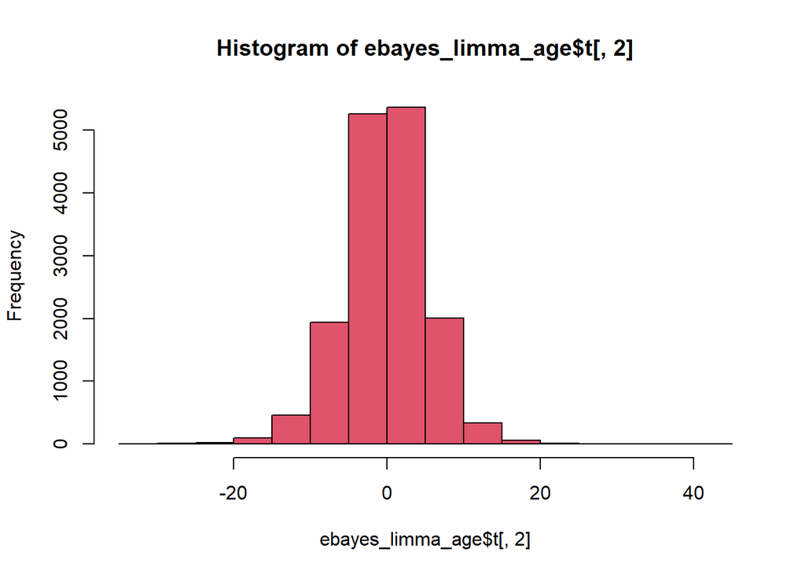

```r
# Statistics
hist(ebayes_limma_age$t[,2], col=2)
```

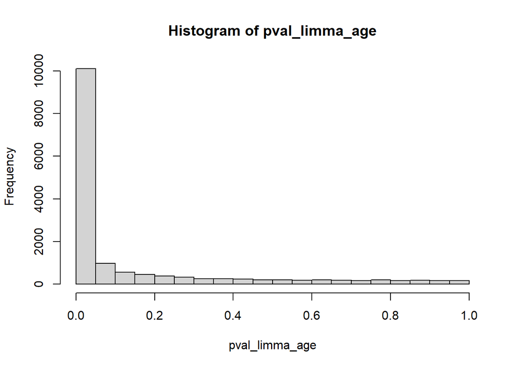

```r
# P-values
pval_limma_age = topTable(ebayes_limma_age, number=dim(edata_tr)[1])$P.Value
hist(pval_limma_age)
```

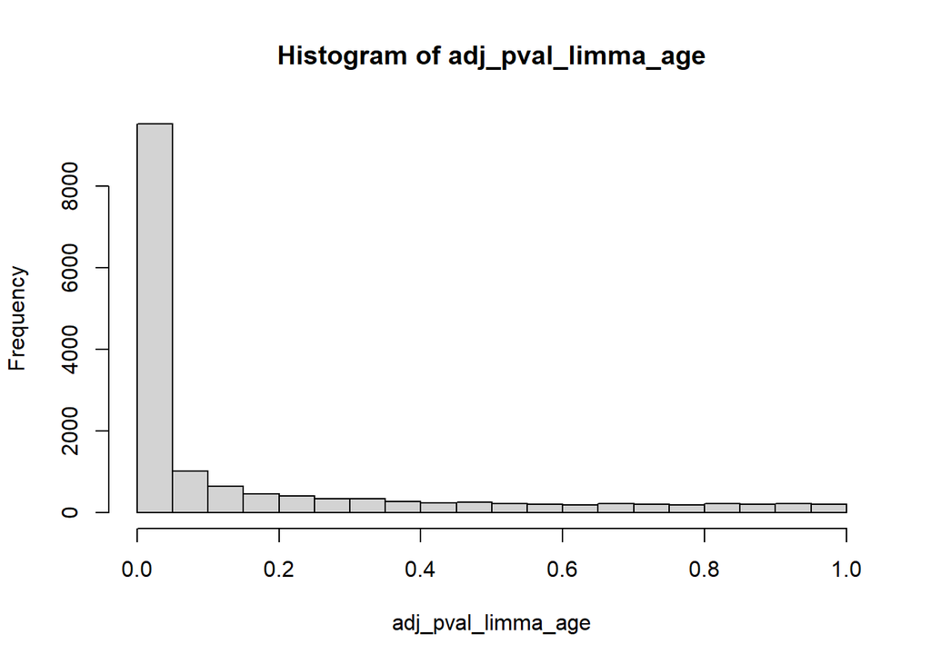

```r
# Adjusted p-values
adj_pval_limma_age = topTable(ebayes_limma_age,number=dim(edata_tr)[1])$adj.P.Val
hist(adj_pval_limma_age)
```

According to the histogram of adjusted p-value, it suggests that there might be an association between age_group variable and gene expression, which means there is a differential gene expression between fetal and adult brains in these samples.

A number of genes have adjusted p-value less than 0.05

```r
sum(re$adj.P.Val < 0.05)
```

```
## [1] 9511
```

#### Fit regression with DESeq

```r
dds <- DESeq(edata)
```

```r
res <- results(dds)
res = as.data.frame(res)
head(res)
```

```
##              baseMean log2FoldChange     lfcSE       stat       pvalue
## A1BG         380.8469    -1.10293610 0.4076920 -2.7053167 6.823930e-03
## ADA          372.3584    -1.86297881 0.4452617 -4.1840088 2.864130e-05
## CDH2       21681.2984     1.36767686 0.1515741  9.0231574 1.827447e-19
## AKT3       27928.4725     1.91781744 0.4513954  4.2486416 2.150707e-05
## ZBTB11-AS1   198.2623     0.06499846 0.2042175  0.3182805 7.502722e-01
## MED6        2117.0608     0.29961394 0.1355707  2.2100194 2.710382e-02
##                    padj
## A1BG       1.190664e-02
## ADA        7.382847e-05
## CDH2       2.284087e-18
## AKT3       5.653192e-05
## ZBTB11-AS1 7.941369e-01
## MED6       4.215816e-02
```

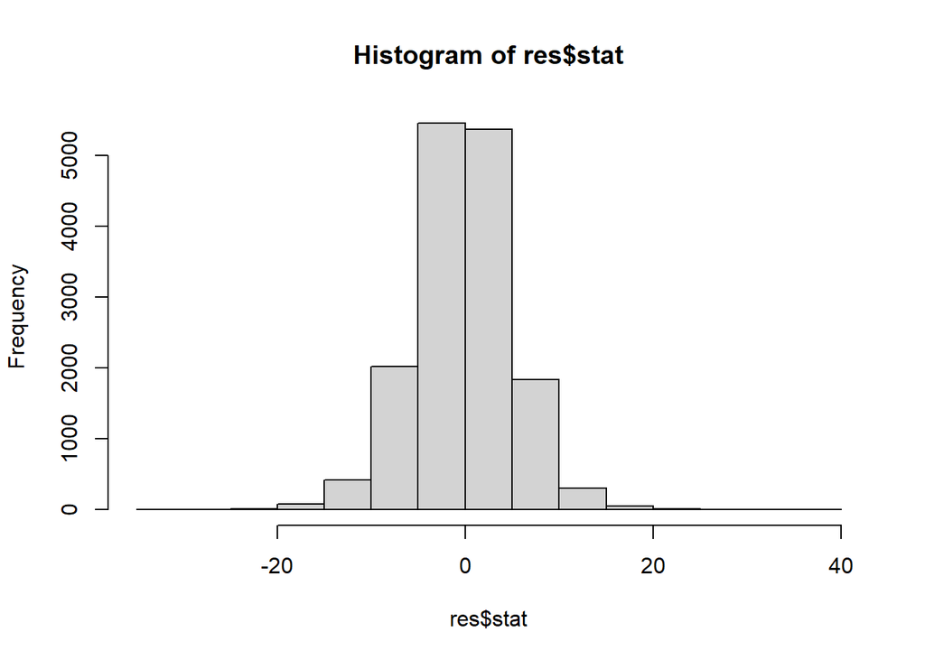

```r
# Statistic
hist(res$stat)
```

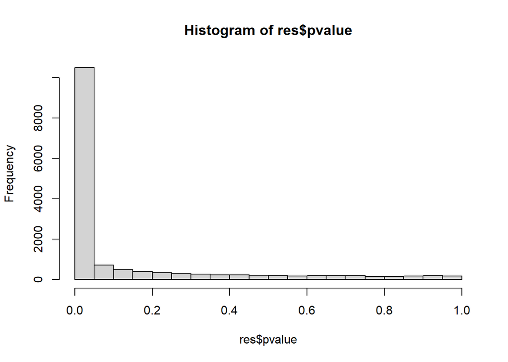

```r
# P-values
hist(res$pvalue)
```

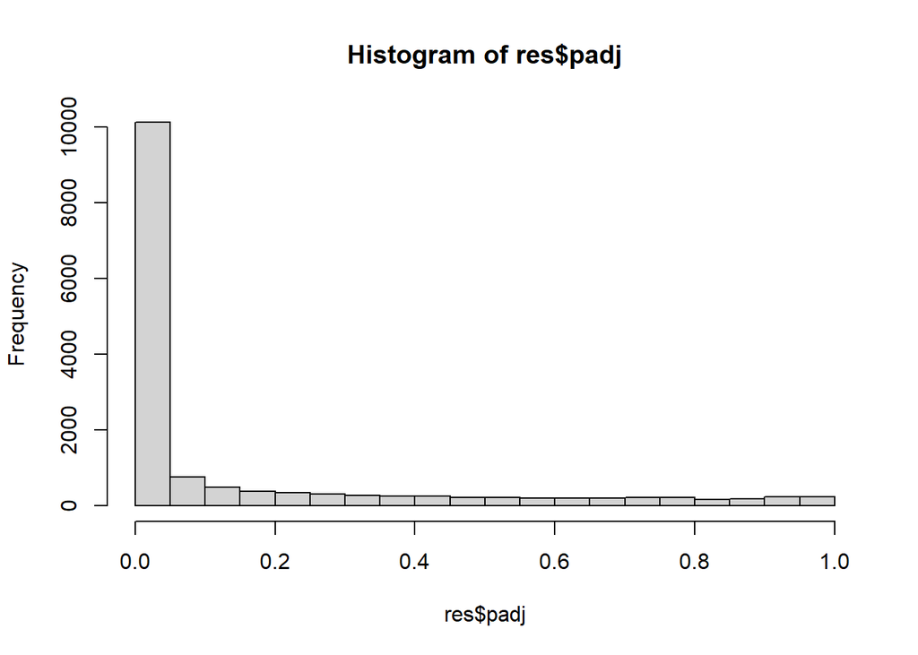

```r
#Adjusted p-values
hist(res$padj)
```

We can see that there is also an association between gene expression with age_group as same as the above result of limma package.

A number of genes have adjusted p-value less than 0.05

```r
table(res$padj <0.05)
```

```
##
## FALSE  TRUE
##  5349 10112
```

### Adjusted data

Because I suspect that sex variable can adjust the association between gene expression with age_group factor, I will analyze statistically data with adjustment factor.

#### Fit regression with limma package with adjustment factor

```r
mod_adj = model.matrix(~ pheno$age_group+pheno$sex)
fit_limma_adj = lmFit(edata_tr,mod_adj)
ebayes_limma_adj <- eBayes(fit_limma_adj)
names(ebayes_limma_adj)
```

```
##  [1] "coefficients"     "rank"             "assign"           "qr"
##  [5] "df.residual"      "sigma"            "cov.coefficients" "stdev.unscaled"
##  [9] "pivot"            "Amean"            "method"           "design"
## [13] "df.prior"         "s2.prior"         "var.prior"        "proportion"
## [17] "s2.post"          "t"                "df.total"         "p.value"
## [21] "lods"             "F"                "F.p.value"
```

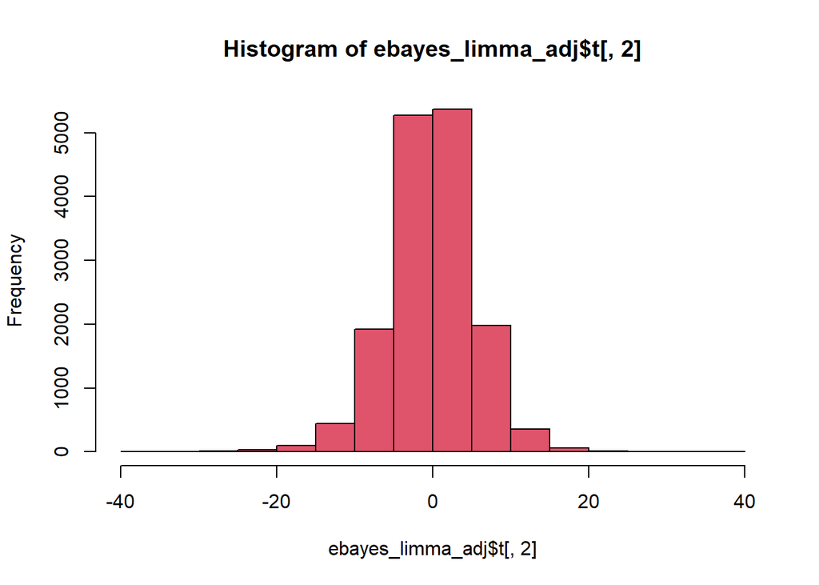

```r
# Statistics
hist(ebayes_limma_adj$t[,2], col=2)
```

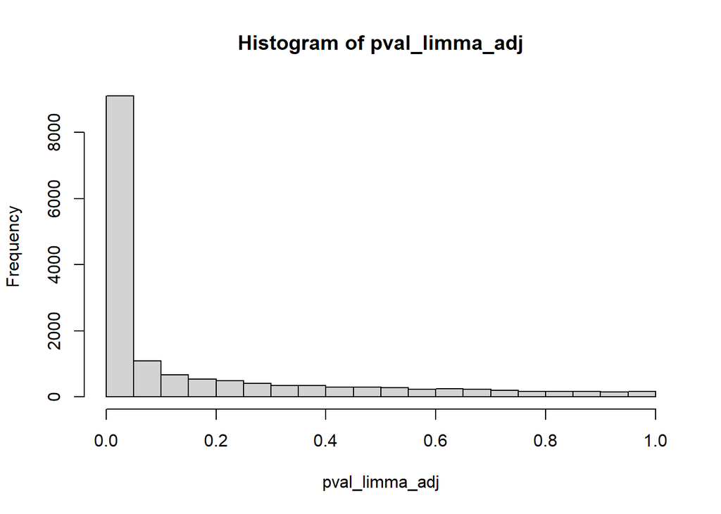

```r
# P-values
pval_limma_adj = topTable(ebayes_limma_adj,number=dim(edata_tr)[1])$P.Value
hist(pval_limma_adj)
```

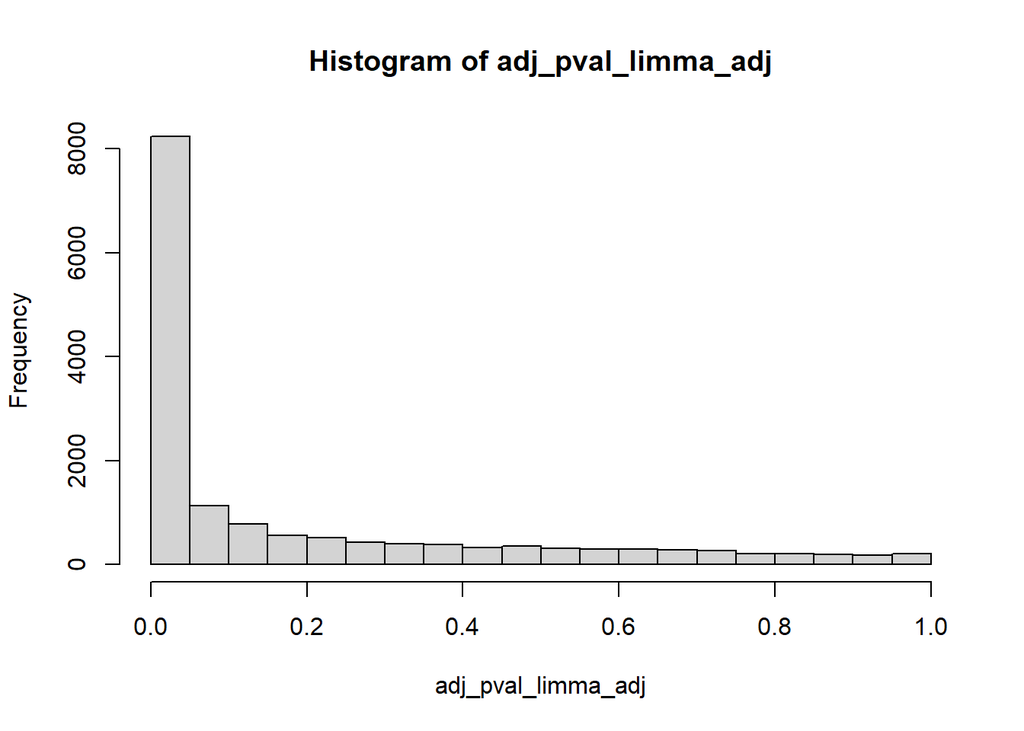

```r
# Adjusted p-values
adj_pval_limma_adj = topTable(ebayes_limma_adj,number=dim(edata_tr)[1])$adj.P.Val
hist(adj_pval_limma_adj)
```

```r
re_adj = topTable(ebayes_limma_adj,number=dim(edata_tr)[1])
head(re_adj)
```

```
##         pheno.age_groupfetus pheno.sexmale   AveExpr        F      P.Value
## ST8SIA2             6.264017   -0.09717847 11.767199 758.4099 1.177104e-11
## SOX11               7.196578   -0.14784492 13.549118 739.4981 1.334594e-11
## SNCG               -6.707473    0.44733611 10.307404 650.4990 2.524224e-11
## NKX6-2             -7.302594    0.82472619  6.955729 588.5204 4.150116e-11
## TRIM54             -6.448248    0.06076597  6.397455 537.9631 6.480537e-11
## SLA                 5.755159   -0.06607231 12.718546 509.9261 8.450284e-11
##            adj.P.Val
## ST8SIA2 1.038247e-07
## SOX11   1.038247e-07
## SNCG    1.309147e-07
## NKX6-2  1.614291e-07
## TRIM54  2.016614e-07
## SLA     2.191300e-07
```

```r
sum(re_adj$adj.P.Val < 0.05)
```

```
## [1] 8232
```

#### Fit regression with DESeq with adjustment factor

```r
de_adj = DESeqDataSetFromMatrix(countData = count_filter, colData = pheno,~ age_group + sex)
glm_all_adj = DESeq(de_adj)
```

```r
results_adj = results(glm_all_adj)
results_adj = as.data.frame(results_adj)
head(results_adj)
```

```
##              baseMean log2FoldChange     lfcSE       stat    pvalue      padj
## A1BG         380.8469     0.12906526 0.4352513  0.2965304 0.7668250 0.9776339
## ADA          372.3584    -0.38152598 0.4613657 -0.8269492 0.4082658 0.9230627
## CDH2       21681.2984    -0.15749391 0.1544875 -1.0194605 0.3079844 0.9171161
## AKT3       27928.4725    -0.07403085 0.4782344 -0.1548003 0.8769787 0.9913890
## ZBTB11-AS1   198.2623    -0.12674096 0.2223552 -0.5699933 0.5686822 0.9462994
## MED6        2117.0608    -0.01682903 0.1510819 -0.1113901 0.9113070 0.9942778
```

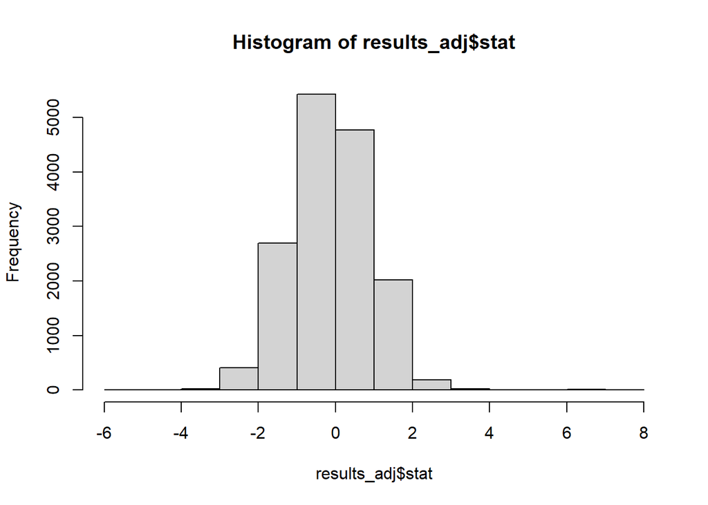

```r
# Statistic
hist(results_adj$stat)
```

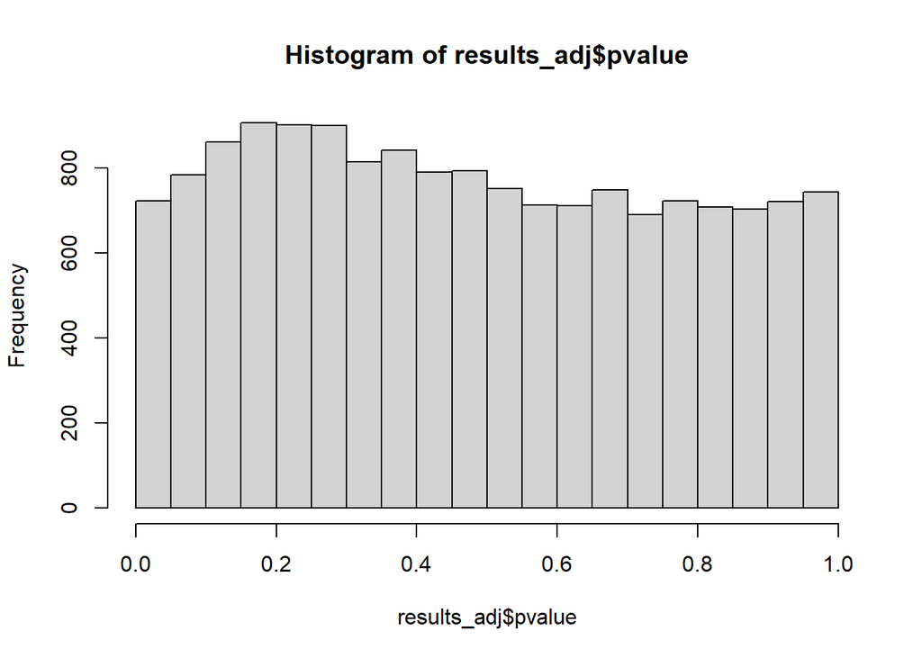

```r
# P-values
hist(results_adj$pvalue)
```

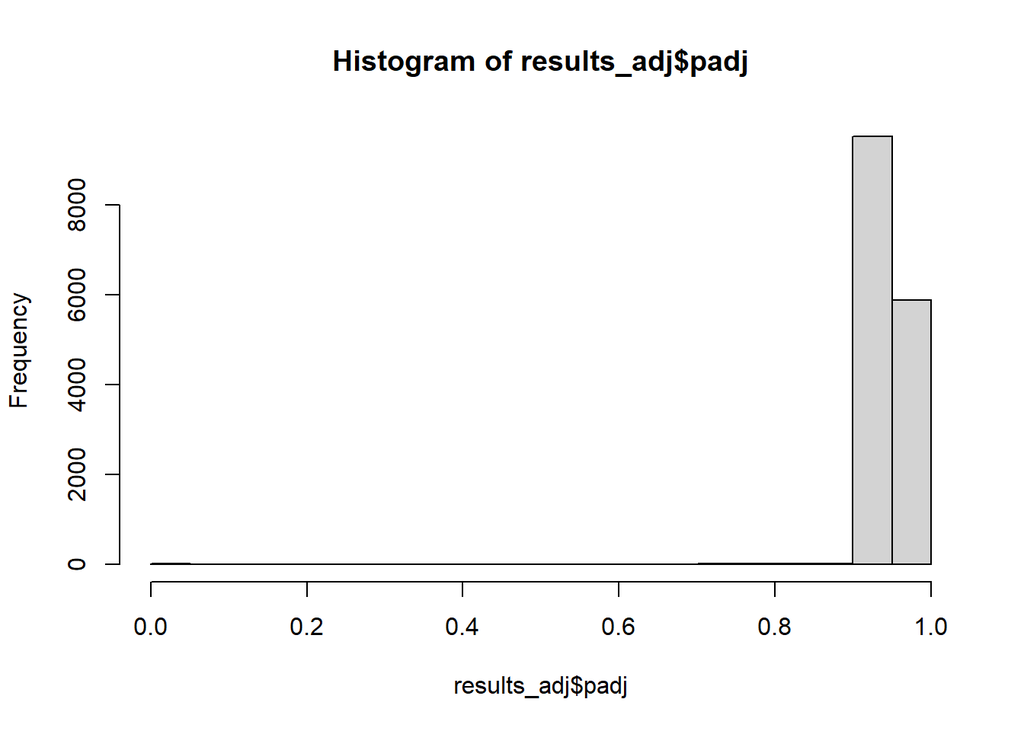

```r
#Adjusted p-values
hist(results_adj$padj)
```

In the adjustment section, we can see that in the limma package, the results having adjusted p-value less than 0.05 are 8232, which also account for about 52.9% in the total of 15559 genes. However, in DESeq package, the results less than 0.05 are a few, and according to the the histogram of results_adj pvalue from DESeq package, it is likely that there is no association between gene expression with adjusted data(including age_group variable and sex variable).

## Count up and down regulated genes

Because of clear evidence of correlation when analyzing unadjusted data, which only have age_group variable, we can see that there is a correlation between the age_group factor and gene expression. Therefore, I will count the up-regulated genes, which are highly expressed and up-regulation in human especially for fetus, and down-regulated genes, which are down-regulation in human especially when getting older and as a result highly appear in the adult than the fetus

I will get up-regulated and down-regulated genes from unadjusted data of both limma package and DESeq package.

### Limma package

**The number of up-regulated genes**

```r
sum(re$adj.P.Val <0.05 & re$logFC > 1)
```

```
## [1] 2560
```

```r
up_limma <- re %>% filter (logFC > 1 & adj.P.Val < 0.05) %>% arrange(adj.P.Val)
head(up_limma)
```

```
##            logFC  AveExpr        t      P.Value    adj.P.Val        B
## ST8SIA2 6.264017 11.76720 40.30384 2.684402e-13 2.770718e-09 20.15611
## SOX11   7.196578 13.54912 39.27425 3.561563e-13 2.770718e-09 19.94839
## SLA     5.755159 12.71855 33.37950 2.100303e-12 8.169655e-09 18.56884
## FBN3    4.918986 11.61649 30.36669 5.882270e-12 1.382686e-08 17.71288
## VASH2   5.011997 11.06801 29.96521 6.798356e-12 1.382686e-08 17.58961
## DCX     5.904494 14.73240 29.23579 8.886727e-12 1.382686e-08 17.35962
```

**The number of down-regulated genes**

```r
sum(re$adj.P.Val <0.05 & re$logFC < -1)
```

```
## [1] 3080
```

```r
down_limma <- re %>% filter (logFC < -1 & adj.P.Val < 0.05) %>% arrange(adj.P.Val)
head(down_limma)
```

```
##            logFC   AveExpr         t      P.Value    adj.P.Val        B
## TRIM54 -6.448248  6.397455 -34.32829 1.547426e-12 8.025467e-09 18.81527
## SNCG   -6.707473 10.307404 -30.34373 5.930876e-12 1.382686e-08 17.70589
## OPALIN -8.692659  8.768713 -29.51529 8.013662e-12 1.382686e-08 17.44869
## SOHLH1 -7.503042  7.626357 -29.37968 8.424990e-12 1.382686e-08 17.40562
## KRT17  -6.499428  5.955451 -27.47641 1.743578e-11 2.466212e-08 16.77083
## UAP1L1 -4.556272  8.839835 -26.51408 2.566615e-11 3.135364e-08 16.42680
```

### DESeq package

**The number of up-regulated genes**

```r
sum(res$padj < 0.05 & res$log2FoldChange > 1, na.rm=TRUE)
```

```
## [1] 3178
```

```r
up_de <- res %>% filter (log2FoldChange > 1 & padj < 0.05) %>% arrange(padj)
head(up_de)
```

```
##           baseMean log2FoldChange     lfcSE     stat        pvalue
## ST8SIA2  21470.986       7.442980 0.2003001 37.15915 3.119957e-302
## SOX11   105896.449       8.543693 0.2330527 36.65991 3.180749e-294
## SLA      33778.704       6.781894 0.2163388 31.34849 1.020083e-215
## FBN3     11490.654       5.816179 0.2007956 28.96568 1.781244e-184
## MEX3B    12548.477       4.157591 0.1503316 27.65614 2.354317e-168
## VASH2     8164.861       5.920934 0.2269659 26.08732 5.077630e-150
##                  padj
## ST8SIA2 4.823766e-298
## SOX11   2.458878e-290
## SLA     5.257168e-212
## FBN3    5.507963e-181
## MEX3B   6.066682e-165
## VASH2   9.813154e-147
```

**The number of down-regulated genes**

```r
sum(res$padj < 0.05 & res$log2FoldChange < -1, na.rm=TRUE)
```

```
## [1] 3853
```

```r
down_de <- res %>% filter (log2FoldChange < -1 & padj < 0.05) %>% arrange(padj)
head(down_de)
```

```
##         baseMean log2FoldChange      lfcSE      stat        pvalue
## BCL2L2 21968.220      -2.676407 0.08831507 -30.30521 9.788276e-202
## SNCG    9473.167      -8.005651 0.29376717 -27.25169 1.587048e-163
## CLMN    3227.245      -3.760479 0.14437310 -26.04695 1.456668e-149
## UAP1L1  1538.034      -5.591225 0.23073417 -24.23232 1.015679e-129
## ITPKA   5882.483      -7.047788 0.29600941 -23.80934 2.673017e-125
## OPALIN  7380.398     -10.922203 0.45988078 -23.75008 1.096772e-124
##                 padj
## BCL2L2 3.783413e-198
## SNCG   3.505336e-160
## CLMN   2.502394e-146
## UAP1L1 1.427583e-126
## ITPKA  3.443960e-122
## OPALIN 1.304400e-121
```

**The number of common up-regulated and also down-regulated genes from both DESeq package and Limma package**

```r
up <- rownames(up_de) %in% rownames(up_limma)
table(up)
```

```
## up
## FALSE  TRUE
##   638  2540
```

```r
down <- rownames(down_de) %in% rownames(down_limma)
table(down)
```

```
## down
## FALSE  TRUE
##   827  3026
```

```r
up = up_de[up,]
head(up)
```

```
##           baseMean log2FoldChange     lfcSE     stat        pvalue
## ST8SIA2  21470.986       7.442980 0.2003001 37.15915 3.119957e-302
## SOX11   105896.449       8.543693 0.2330527 36.65991 3.180749e-294
## SLA      33778.704       6.781894 0.2163388 31.34849 1.020083e-215
## FBN3     11490.654       5.816179 0.2007956 28.96568 1.781244e-184
## MEX3B    12548.477       4.157591 0.1503316 27.65614 2.354317e-168
## VASH2     8164.861       5.920934 0.2269659 26.08732 5.077630e-150
##                  padj
## ST8SIA2 4.823766e-298
## SOX11   2.458878e-290
## SLA     5.257168e-212
## FBN3    5.507963e-181
## MEX3B   6.066682e-165
## VASH2   9.813154e-147
```

```r
down = down_de[down,]
head(down)
```

```
##         baseMean log2FoldChange      lfcSE      stat        pvalue
## BCL2L2 21968.220      -2.676407 0.08831507 -30.30521 9.788276e-202
## SNCG    9473.167      -8.005651 0.29376717 -27.25169 1.587048e-163
## CLMN    3227.245      -3.760479 0.14437310 -26.04695 1.456668e-149
## UAP1L1  1538.034      -5.591225 0.23073417 -24.23232 1.015679e-129
## ITPKA   5882.483      -7.047788 0.29600941 -23.80934 2.673017e-125
## OPALIN  7380.398     -10.922203 0.45988078 -23.75008 1.096772e-124
##                 padj
## BCL2L2 3.783413e-198
## SNCG   3.505336e-160
## CLMN   2.502394e-146
## UAP1L1 1.427583e-126
## ITPKA  3.443960e-122
## OPALIN 1.304400e-121
```

As we can see, there are 2540 common up-regulated genes and 3026 common down-regulated genes between limma package and DESeq package.

In addition to analyzing the correlation in R, I also want to predict and classify some characteristics of those 10 samples such as gender, or age by using Python. Below is the preparation for that process.

## Preparing data for prediction and classification

```r
up_down_reg = rbind(up,down)
dim(up_down_reg)
```

```
## [1] 5566    6
```

```r
up_down_tr <- (rownames(edata_tr) %in% rownames(up_down_reg))
table(up_down_tr)
```

```
## up_down_tr
## FALSE  TRUE
##  9993  5566
```

```r
up_down = edata_tr[up_down_tr,]
head(up_down)
```

```
##         SRR1554534 SRR1554535 SRR1554568 SRR1554561 SRR1554567 SRR1554536
## ADA       8.646385   9.145974   7.303994   8.001912   7.351627   9.770115
## CDH2     13.562468  13.585906  14.957846  13.652418  14.829826  13.812075
## AKT3     13.479431  13.159273  15.876052  13.925121  14.376621  12.332018
## ACOT8    11.946038  11.757942  10.652184  12.014095  10.470291  11.250633
## ZBTB33   11.724310  12.137270  13.056753  11.858819  12.975194  11.759541
## ZSCAN30  11.187060  11.583213  12.612542  11.040663  12.383769  11.699403
##         SRR1554541 SRR1554539 SRR1554538 SRR1554537
## ADA       7.843839   8.253862   7.831596   7.197164
## CDH2     14.545283  13.717079  14.708753  15.051336
## AKT3     15.204848  14.383520  14.749481  15.584859
## ACOT8    10.522167  11.461451  10.601639  10.700495
## ZBTB33   12.988798  12.410141  13.263124  13.212136
## ZSCAN30  12.182915  11.462477  12.586344  12.277068
```

```r
# df is saved in a name "data for regulated gene.csv"
df <- merge(up_down_reg,up_down, by =0)
row.names(df) <- df$Row.names
df = df[,-1]
head(df)
```

```
##          baseMean log2FoldChange     lfcSE       stat       pvalue         padj
## A2M    13185.3832      -1.670680 0.4204894  -3.973179 7.091974e-05 1.717291e-04
## A2ML1    484.6328      -2.748295 0.5692828  -4.827644 1.381576e-06 4.322248e-06
## A4GALT   412.3115      -2.790862 0.5719644  -4.879432 1.063917e-06 3.379052e-06
## AARD     124.8856      -2.105662 0.5372000  -3.919699 8.865947e-05 2.115377e-04
## AARS1  33645.6493      -1.564934 0.2709131  -5.776517 7.626273e-09 3.150984e-08
## AATK   21134.6178      -3.684225 0.3588961 -10.265435 1.008658e-24 1.959154e-23
##        SRR1554534 SRR1554535 SRR1554568 SRR1554561 SRR1554567 SRR1554536
## A2M     13.657416  13.795969  12.584194  13.003245  12.597035  15.235020
## A2ML1    8.848175   9.062477   6.909735   8.644313   7.457088  10.622862
## A4GALT   8.868851   8.344972   6.895125   8.568670   6.710507  10.362960
## AARD     7.347104   7.314591   5.402734   6.636227   6.395016   7.306073
## AARS1   15.757594  15.345289  14.133470  15.908997  14.037013  14.566318
## AATK    15.412314  15.065392  11.532492  15.465764  11.828298  13.675639
##        SRR1554541 SRR1554539 SRR1554538 SRR1554537
## A2M     12.938130  13.881265  12.930901  12.535831
## A2ML1    6.885452   7.708383   7.500564   7.351208
## A4GALT   7.260562   7.533763   7.292369   6.723675
## AARD     6.484457   7.470666   5.264764   5.737391
## AARS1   14.312565  15.532491  14.157486  14.182287
## AATK    12.056377  14.628722  11.641881  12.151114
```

```r
# save file
# write.csv(df, file = "D:/word/bioinformatics/personal project/genomic-data-science-project-about-fetus-and-adult/tidy data/data for regulated gene.csv")
```